# 2018 Model Extension

Sean Davern

June 18, 2019

# Overview

This notebook extends the modeling done in 2013 to include data through much of 2018.

# Load Data

Loading cleaned and transformed giving data:

```r
df <- readRDS("../data/Cleaned and Transformed Giving Data.rds")
head(df)
```

| week.ending | month | year | total | monthly.giving.families | SundaysInMonth | MonthsGivingPerWeek |
| --- | --- | --- | --- | --- | --- | --- |
| 2010-01-31 | January | 2010 | 14241.15 | 45 | 5 | 2848.230 |
| 2010-02-28 | February | 2010 | 22437.50 | 41 | 4 | 5609.375 |
| 2010-03-28 | March | 2010 | 13317.00 | 32 | 4 | 3329.250 |
| 2010-04-25 | April | 2010 | 13232.50 | 36 | 4 | 3308.125 |
| 2010-05-30 | May | 2010 | 13478.15 | 40 | 5 | 2695.630 |
| 2010-06-27 | June | 2010 | 14930.50 | 43 | 4 | 3732.625 |

# Columns to Accomodate Analysis

I’ll add a few columns to enable asking analysis “what if’s” and adjust for anomolies:

```r
library("dplyr", quietly=TRUE, warn.conflicts = FALSE)
df <- mutate(df,
             excluded = FALSE,
             removed.amount = 0,
             original.total = total)
```

# Accommodating Unusual Gift

```r
df$removed.amount[as.Date(df$week.ending) == "2016-12-25"] <- 20000
df$total <- df$original.total - df$removed.amount
#df$excluded[as.Date(df$week.ending) == "2016-12-25"] <- TRUE
```

Note: we’re not excluding the 3 months consider “outliers” in the 2013 analysis. Now with 9 years of history, those months don’t appear as much to be outliers.

# Modeling

Regressing the R version of the 2013 model:
$$\textit{Monthly Giving} = a+b_{year}+c_{month}$$

```r
mod <- lm(
  formula = total ~
    year + month,
  data = df[df$excluded!=TRUE,]
)
```

…gives the following

# Model Predictions

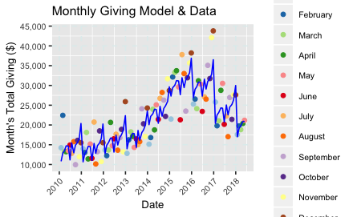

# Model Fit Assessment

```
Analysis of Variance Table

Response: total
          Df     Sum Sq   Mean Sq F value    Pr(>F)
year       8 3920266253 490033282  30.198 < 2.2e-16 ***
month     11  588525930  53502357   3.297  0.000896 ***
Residuals 81 1314433124  16227569
---
Signif. codes:  0 ‘***’ 0.001 ‘**’ 0.01 ‘*’ 0.05 ‘.’ 0.1 ‘ ’ 1
```

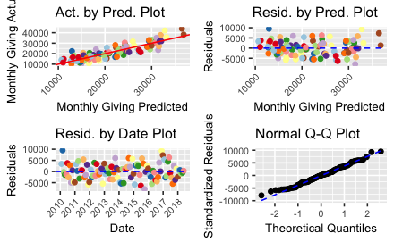

Both model terms are highly statistically significant. The residuals seem nicely randomly scattered. I don’t see any particularly concerning patterns in the plots including model biases by month (dot color). The quantile plot shows very normally distributed residuals.

# Regressed Model Details

```
Call:
lm(formula = total ~ year + month, data = df[df$excluded != TRUE,
    ])

Residuals:
    Min      1Q  Median      3Q     Max
-7904.4 -2659.0    46.1  2486.6  9513.2

Coefficients:
               Estimate Std. Error t value Pr(>|t|)
(Intercept)     10807.3     1741.1   6.207 2.18e-08 ***
year2011         -133.7     1644.6  -0.081  0.93542
year2012         1974.0     1644.6   1.200  0.23352
year2013         3165.1     1644.6   1.925  0.05779 .
year2014         9265.5     1644.6   5.634 2.47e-07 ***
year2015        16494.5     1644.6  10.030 7.42e-16 ***
year2016        16124.2     1644.6   9.805 2.05e-15 ***
year2017         9597.9     1644.6   5.836 1.06e-07 ***
year2018         6215.8     2198.7   2.827  0.00592 **
monthFebruary    2117.0     1899.0   1.115  0.26824
monthMarch       2739.3     1899.0   1.443  0.15301
monthApril       3918.4     1899.0   2.063  0.04227 *
monthMay         3833.6     1899.0   2.019  0.04682 *
monthJune         359.5     1968.9   0.183  0.85559
monthJuly        4648.5     1968.9   2.361  0.02063 *
monthAugust      2149.1     1968.9   1.092  0.27828
monthSeptember   4115.6     1968.9   2.090  0.03973 *
monthOctober     4765.5     1968.9   2.420  0.01774 *
monthNovember    5895.7     1968.9   2.994  0.00365 **
monthDecember    9574.9     1968.9   4.863 5.59e-06 ***
---
Signif. codes:  0 ‘***’ 0.001 ‘**’ 0.01 ‘*’ 0.05 ‘.’ 0.1 ‘ ’ 1

Residual standard error: 4028 on 81 degrees of freedom
Multiple R-squared:  0.7743,    Adjusted R-squared:  0.7213
F-statistic: 14.62 on 19 and 81 DF,  p-value: < 2.2e-16
```

# Model Generalization

We can generalize the model again, as described in the “Transfer of 2013 Analysis” Notebook, by shifting the coefficients to the average month and year like this:
$$\textit{Monthly Giving}
= \big[a+\overline{b_{year}}+\overline{c_{month}}\big]+
\big(b_{year}-\overline{b_{year}}\big)+
\big(c_{month}-\overline{c_{month}}\big)$$
where $\overline{b_{year}}$ is the mean of $b_{year}$ coefficients, including $b_{2010}=0$, and $\overline{c_{month}}$ is the mean of the $c_{year}$ coefficients, including $c_{January}=0$.

# Monthly Variation

This plot shows the resulting $month$ regression coeffiecients shifted by $\overline{c_{month}}$ capturing month-to-month variation. ($(c_{month}-\overline{c_{month}})$) The shape of the yearly repeated pattern in the prediction are the result of these terms.

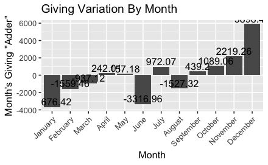

This plot is generally similar to Figure 13 in the 2013 Analysis with the exception of November. Since it is based on 9 years of Seed history, I’ll judge that it is more representative of an average year.